# Homework 1 - PSTAT131

### Exercise 4

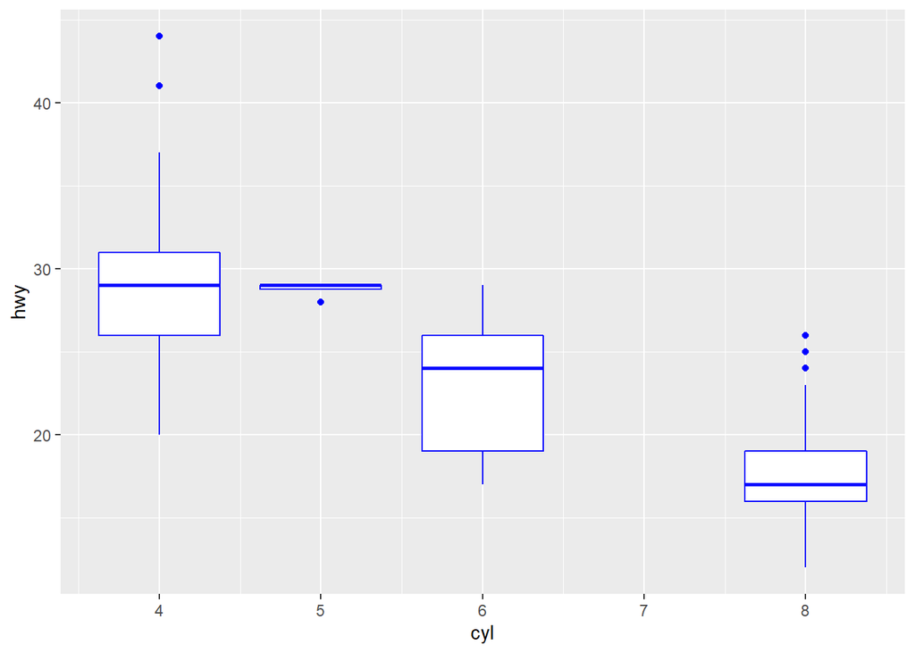

```r
# Generating Boxplots for hwy grouped by cyl
chart <- ggplot(data = mpg, aes(x = cyl, y = hwy, group = cyl)) + geom_boxplot(color = "blue")
chart
```

### Exercise 6

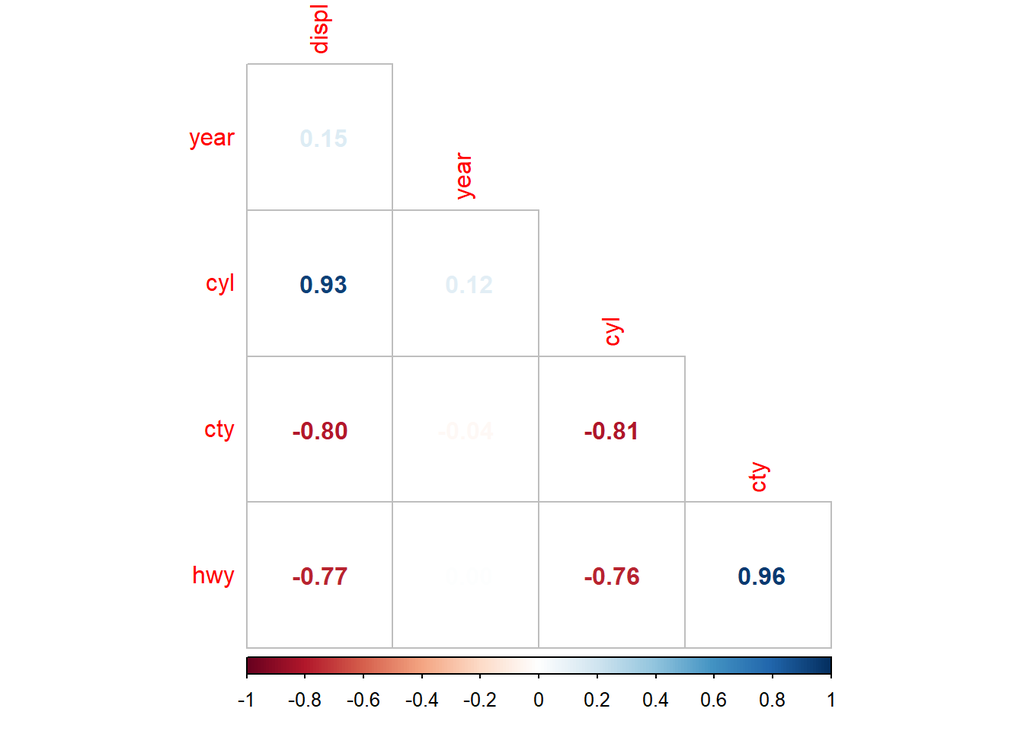

```r
# Generating the lower triangle correlation matrix with numbers

# Removing non-numeric variables as errors are generated when trying to find the coefficient of correlation for character variables
mpgSubset = subset(mpg,select = - c(manufacturer, model, trans, drv, fl, class))

M <- cor(mpgSubset)
corrplot(M, method = "number", type = "lower", diag = FALSE)
```

The variables that are negatively correlated with eachother are (city vs. displacement), (highway mpg vs displacement), (city mpg vs cylinders), (highway mpg vs cylinders), and (city mpg vs year)

One correlation that did not surprise me is city mpg vs highway mpg. One would assume that they would almost have a 1:1 correlation with eachother since a car with bad city mpg, generally probably has a bad highway mpg vice-verse.

One correlation that I was very surprised by was year vs city and highway mpg. I thought for sure that we have made great steps in mpg over the years and you would see a strong positive correlation. According to this dataset though, this is not true.